# 0.0: Before You Start

Becca

Updated August 2019

This is a brief introduction to the R Studio program, including some best practice recommendations on how to save files and scripts. If you are already familiar with R Studio and have a file-organization system that works for you, please feel free to skip this introduction!

The program we recommend for working with R is R Studio: (https://www.rstudio.com/products/rstudio/download/#download).

[figure not shown]

Once downloaded, go ahead and open the program.

The basic layout of **R** studio is:

1. A sript editor in the top-left quadrat (if you can’t see the script editor right away, click on the little ‘tab’ button, circled in red),
2. A console in the bottom-left quadrat,
3. An environment tab in the top-right quadrat,
4. An output/files/packages tab in the bottom-right quadrat.

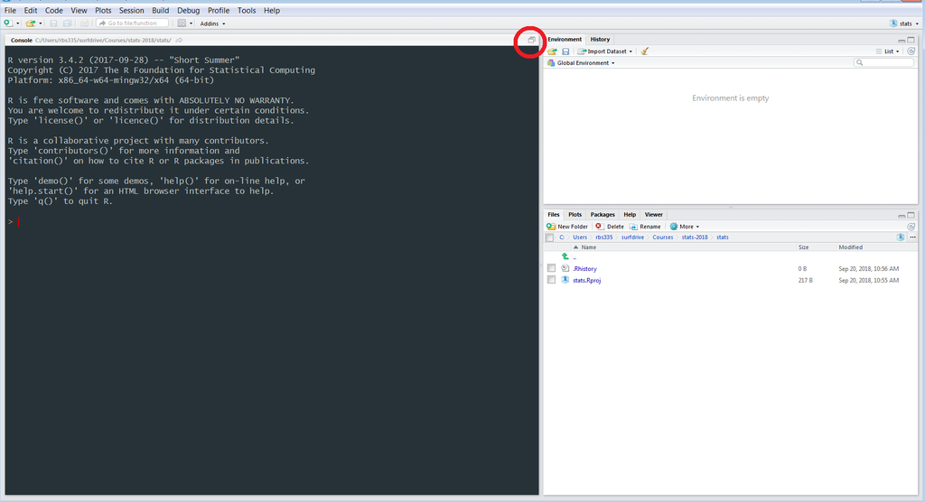

As a general rule, the console is where you try things out and mess around with calculations, and the script is where you write the things you would like to save for later, just like you would save an essay in Word (to save a script, just click on File->Save As and choose where to save it).

In this script, I have written some comments (a ‘#’ sign in front of a line of text tells R that this is not code).

I have also written a basic calculation (’3*5’) to show how R can be used as a calculator. To run code from a script, select the line(s) you would like to run and press [Ctrl][Enter], the output should appear in your console.

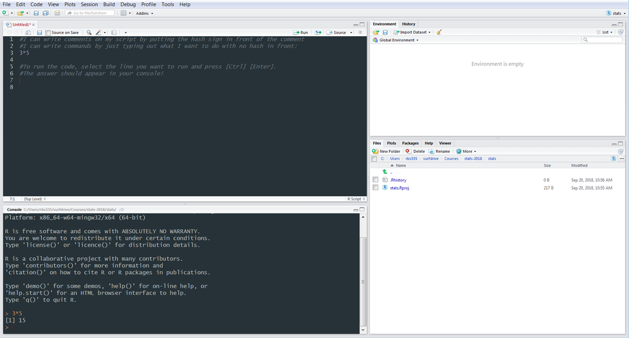

The operations we can perform in R will be covered in more detail in the main assignment - this is just to show you what the script editor looks like.

> A note about saving things:

[figure not shown]

Now let’s try saving an example script to the ‘day-1’ folder. First, set your working directory to the EDA-2018 folder (change the YOUR-USERNAME to your own). This is a command that will be very useful for your assignments, assuming you save everything to a common folder.

```
#set your working directory:


setwd("C:/Users/YOUR-USERNAME/Desktop/EDA-2018")
```

Run the code to see if it works. If it works, you should see the code copied in your console without any error messages (you can also check that the command worked by typing `getwd()` into the console and pressing [Enter] to see if the working directory is the same as the one you have typed in).

You can also add in some calculations or comments if you want:

```
#Some example things to add to your script,
#this is just to test it out.

3*5

17-2
```

Next, go to ‘File -> Save As’ and save to the day-1 folder. I will call my script ‘test-1’.

Now, you should be easily able to locate your test script in your day-1 folder, and go back to edit it whenever you want!

We’re going to practice importing a dataset from the course Canvas page, so that you’ll know how to get started with your assignments in R.

First, navigate to the course Canvas page and go to Pages. You should see a page called Introduction to R and Basic Stats.

[figure not shown]

Under the section ‘Practical Monday 1 October’ you should see a file called ‘ward.csv’. Download the file and save it in your day-1 folder as ward.csv (note: the computer will probably give you a warning about csv files, this is fine! Just save it anyway).

Now go ahead and open up your ‘test-1’ script again (or maybe it is still open on your computer). We are going to read in the .csv file from the day-1 folder where you saved it. Since you have already set your working directory to the EDA-2018 folder, this should be really easy! All you have to add to your script is:

```
ward <- read.csv("day-1/ward.csv", header=TRUE)
```

And there you have it! If it worked, you should be able to see ‘ward’ in the environment tab in the top-right quadrat of the R studio window (circled in red below).

[figure not shown]

**To break down what just happened:** you already set your working directory by using the `setwd()` command and pressing [Ctrl][Enter] to run the command. R Studio was already looking in your EDA-2018 folder, so when you wanted to read in the ward.csv file, which you saved in the day-1 folder, you only had to specify the day-1 folder in your file path (ie, you didn’t have to re-type the entire path name).

Sorting your files into a central place makes reading in files super convenient, and if you are careful to save your files and scripts into the EDA-2018 folder, you will never have to type in a full path name again (just be sure to change the day-1 in our example to whatever folder you’ve saved the file to)!

If you want to look at the data you just read in, you can type `summary(ward)` or `View(ward)` into your console and press [Enter], or you could type it into your script and press [Ctrl][Enter].

[figure not shown]

Reading in the ward.csv file was pretty easy because it follows a typical .csv structure. However, sometimes your data gets really messed up when you read in a file this way, or R just refuses to read it in and gives you an error. This topic is addressed in section *5* of the introductory assignment, and gives you many options for how to read in a file if the normal `read.csv()` command doesn’t seem to be working.

R is a real asset to scientists as it allows us to save and recreate our analyses, and allows us to share our data and analyses with others. The purpose of using this program is to serve your scientific goals; you should not be a slave to the program. To this end, R Studio has made things even easier for non-technical users to get started with fully reproducible data analysis.